# Lab4P1

```r
atividade = read_projectdata()
atividade = atividade %>%
  filter(seguidores > 0, n_proprio > 0, n_retweet > 0)
```

```r
glimpse(atividade)
```

```
## Observations: 295
## Variables: 19
## $ id_parlamentar        <chr> "204528", "178836", "160559", "204545", "2…
## $ casa                  <chr> "câmara", "câmara", "câmara", "câmara", "c…
## $ nome_eleitoral        <chr> "ADRIANA VENTURA", "ALAN RICK", "ALCEU MOR…
## $ partido               <chr> "NOVO", "DEM", "MDB", "PSL", "PT", "PSL", …
## $ UF                    <chr> "SP", "AC", "RS", "MG", "SP", "SP", "SP", …
## $ twitter               <chr> "adrianasounovo", "Alan_Rick", "Alceu_More…
## $ seguidores            <dbl> 4652, 3983, 6370, 464, 6447, 161745, 1134,…
## $ segue                 <dbl> 315, 995, 434, 267, 3253, 2015, 140, 1035,…
## $ n_proprio             <dbl> 99, 49, 214, 39, 346, 830, 58, 485, 1, 201…
## $ n_retweet             <dbl> 9, 1, 30, 4, 100, 169, 15, 204, 1, 95, 45,…
## $ engaj_total           <dbl> 7090, 4286, 6852, 10231, 69348, 566011, 30…
## $ engaj_total_proprio   <dbl> 6701, 284, 2239, 186, 47967, 320063, 23, 8…
## $ engaj_total_retweet   <dbl> 389, 4002, 4613, 10045, 21381, 245948, 7, …
## $ engaj_mediano         <dbl> 26.5, 4.0, 8.0, 4.0, 16.5, 134.0, 0.0, 49.…
## $ engaj_mediano_proprio <dbl> 22.5, 4.0, 8.0, 4.0, 12.0, 60.0, 0.0, 27.0…
## $ engaj_mediano_retweet <dbl> 0.0, 0.0, 0.0, 0.0, 0.0, 0.0, 0.0, 0.0, 0.…
## $ engaj_max             <dbl> 1031, 4002, 4227, 8171, 12335, 20348, 4, 3…
## $ engaj_max_proprio     <dbl> 1031, 38, 136, 14, 12335, 7271, 4, 3643, 1…
## $ engaj_max_retweet     <dbl> 99, 4002, 4227, 8171, 8623, 20348, 2, 3302…
```

# 1. Qual a relação entre as características da atuação do parlamentar e o engajamento total que ele obtém no twitter?

## Investigando as variáveis

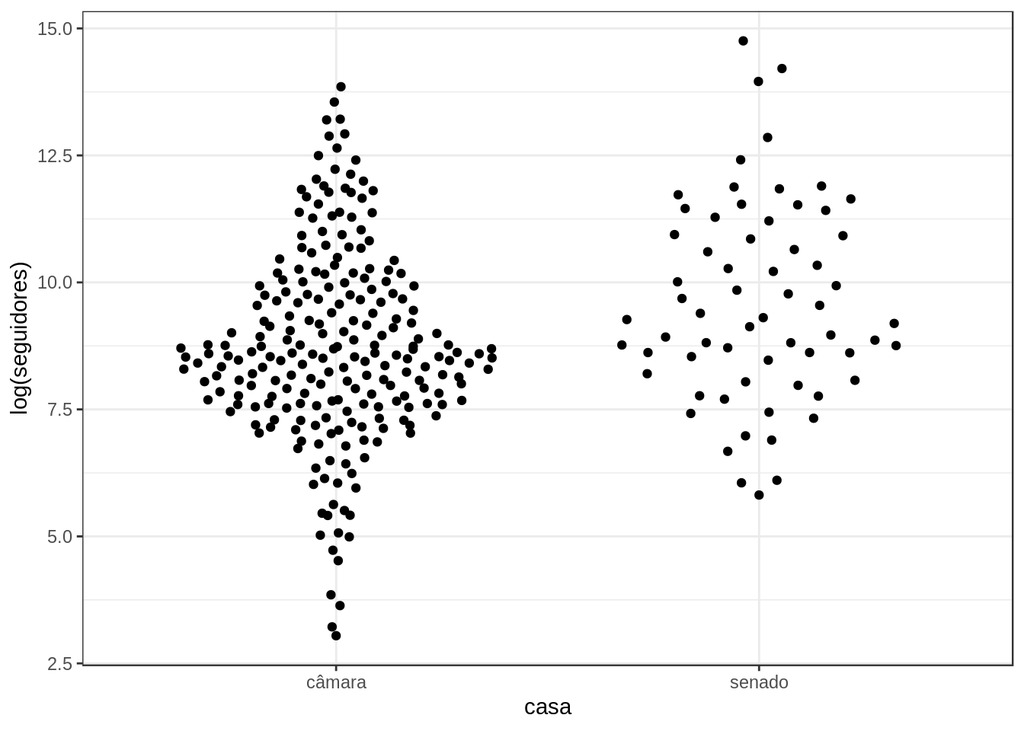

```r
atividade %>% ggplot(aes(x =  casa,y = log(seguidores))) +
  ggbeeswarm::geom_quasirandom()
```

Foi utilizado o log dos seguidores pois os valores apresentavam potências grandes e ficava de difícil vizualização. Fiz a visualização acima para tentar ver se existe alguma relação entre a quantidade de seguidores e casa ao qual o politico pertence. Porém a distribuição não aparenta ter concentrações. Ou seja, não PARECE haver relação entre a quantidade de seguidores e a casa ao qual o político pertence.

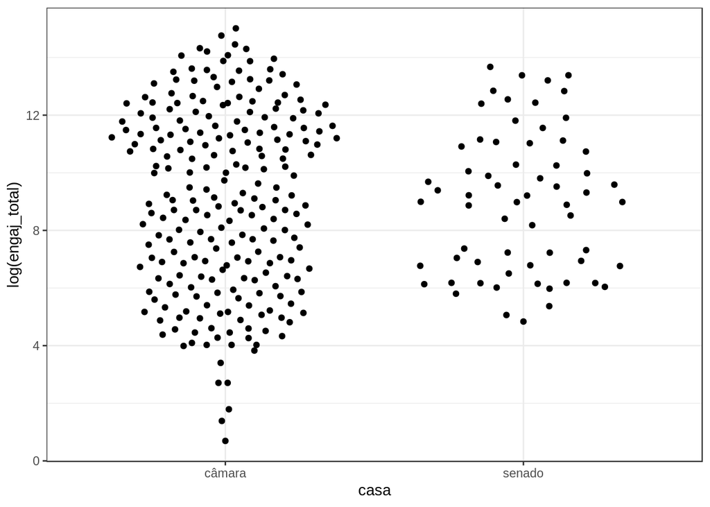

```r
atividade %>% ggplot(aes(x =  casa,y = log(engaj_total))) +
   ggbeeswarm::geom_quasirandom()
```

O mesmo foi feito para o engajamento total e obtivemos resultado similar ao supracitado. Assim parece que a variável ‘casa’ não parece ser muito explicativa para o engajamento total.

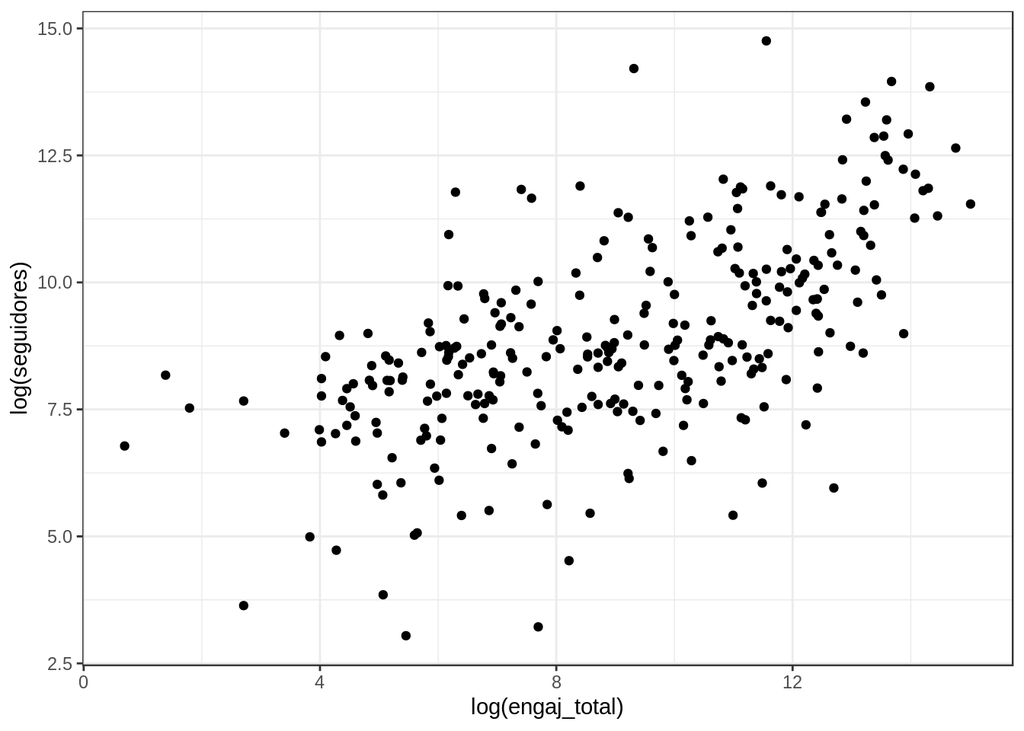

```r
atividade %>% ggplot(aes(x = log(engaj_total), y = log(seguidores))) +
geom_point()
```

No plot acima tivemos que aplicar a tranformação de log devido aos valores altos das variáveis. No plot podemos observar uma relação que parece ser linear entre o log do numero de seguidores e o engajamento total.

```r
cor_engaj_total_seguidores <- cor(log(atividade$engaj_total), log(atividade$seguidores))
glimpse(cor_engaj_total_seguidores)
```

```
##  num 0.603
```

Existe uma correlação linear de 0,6 entre as variaveis transformadas utilizando log. Parece que a variável seguidores é bastante significativa para o engaj_total

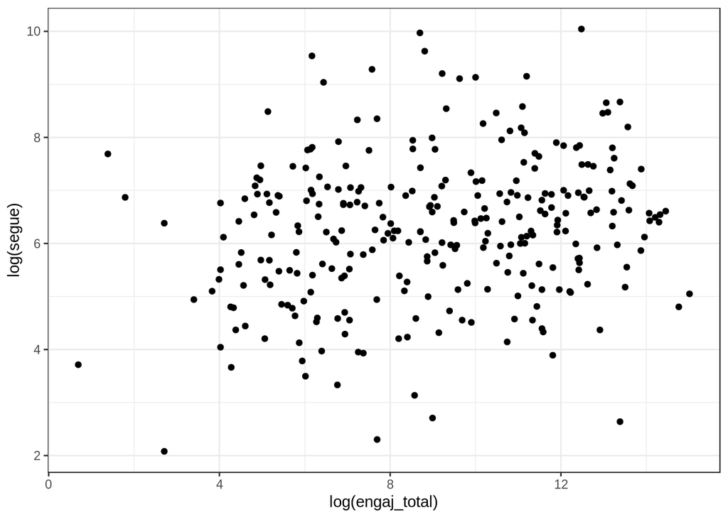

```r
atividade %>% ggplot(aes(x = log(engaj_total), y = log(segue))) +
geom_point()
```

```r
cor(log(atividade$engaj_total), log(atividade$segue))
```

```
## [1] 0.1952791
```

Não parece exister um correlação linear plausivel entre quantidade de pessoas que segue e o engajamento total. A variável segue não perece ser significativa para a variável engajamento total.

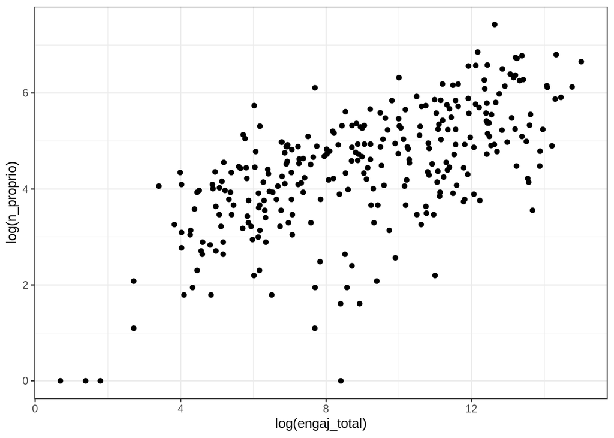

```r
atividade %>% ggplot(aes(x = log(engaj_total), y = log(n_proprio))) +
geom_point()
```

```r
cor(log(atividade$engaj_total), log(atividade$n_proprio))
```

```
## [1] 0.6431369
```

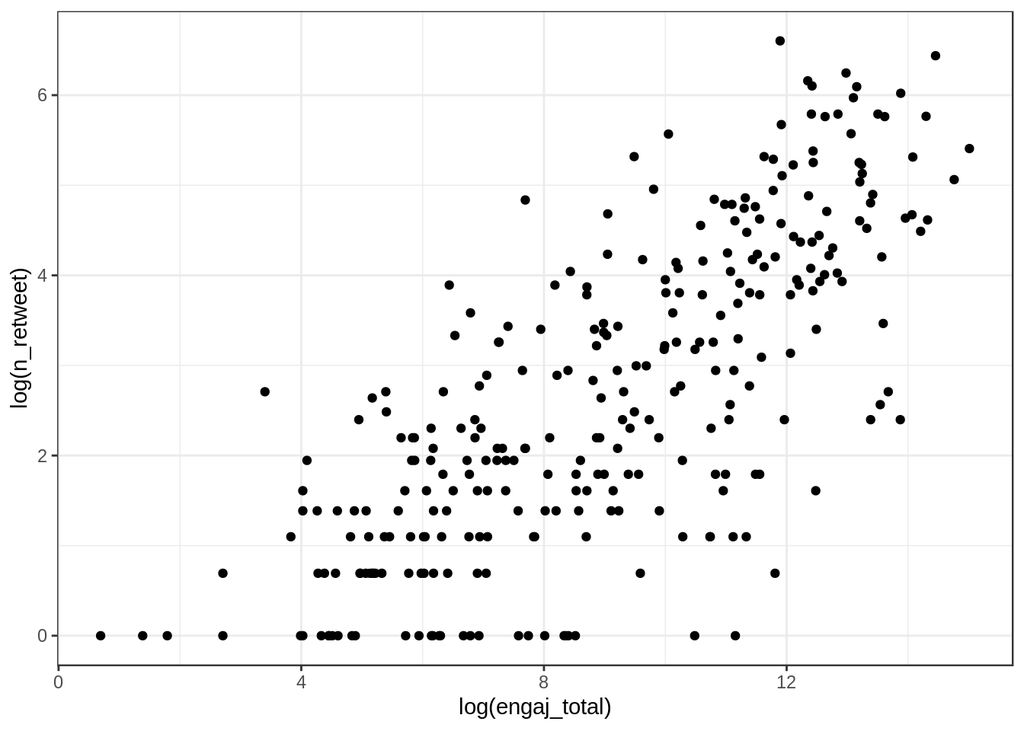

```r
atividade %>% ggplot(aes(x = log(engaj_total), y = log(n_retweet))) +
geom_point()
```

A quantidade de tweets não contanto retweets paeece ser significativa para o engajemnto total. Assim como a quantidade de retweets. O que já era esperado.

```r
modelo_eng_total <- lm(log(engaj_total) ~ casa + log(segue) +  log(seguidores) + log(n_proprio) + log(n_retweet),
                       data = atividade)

glance(modelo_eng_total)
```

| r.squared | adj.r.squared | sigma | statistic | p.value | df | logLik | AIC | BIC | deviance | df.residual |
| --- | --- | --- | --- | --- | --- | --- | --- | --- | --- | --- |
| 0.7136951 | 0.7087417 | 1.627658 | 144.0827 | 2.60379e-76 | 6 | -559.2629 | 1132.526 | 1158.335 | 765.6394 | 289 |

```r
tidy(modelo_eng_total)
```

| term | estimate | std.error | statistic | p.value |
| --- | --- | --- | --- | --- |
| (Intercept) | 1.1202723 | 0.58749952 | 1.9068480 | 5.753177e-02 |
| casasenado | -0.1161423 | 0.24042356 | -0.4830738 | 6.294091e-01 |
| log(segue) | -0.2819380 | 0.07592146 | -3.7135482 | 2.452250e-04 |
| log(seguidores) | 0.5696910 | 0.05675132 | 10.0383741 | 1.544425e-20 |
| log(n_proprio) | 0.5147557 | 0.09898274 | 5.2004589 | 3.769707e-07 |
| log(n_retweet) | 0.8760765 | 0.07381089 | 11.8692035 | 9.810965e-27 |

# 2. Qual a relação entre as características da atuação do parlamentar e o *engajamento mediano* que ele obtém no twitter?

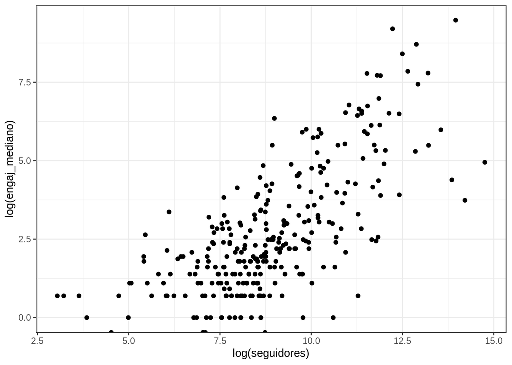

```r
atividade %>% ggplot(aes(y =log(engaj_mediano), x = log(seguidores))) +
geom_point()
```

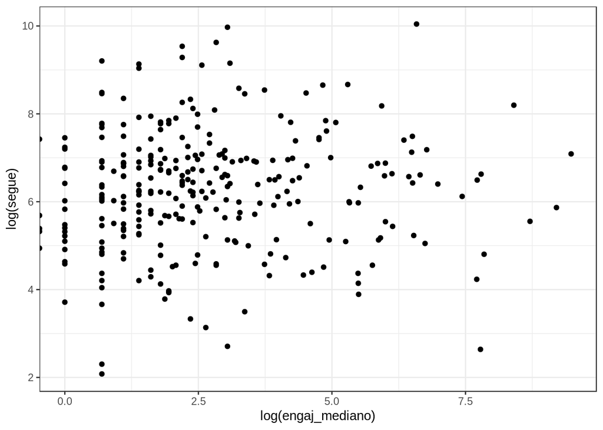

```r
atividade %>% ggplot(aes(x = log(engaj_mediano), y = log(segue))) +
geom_point()
```

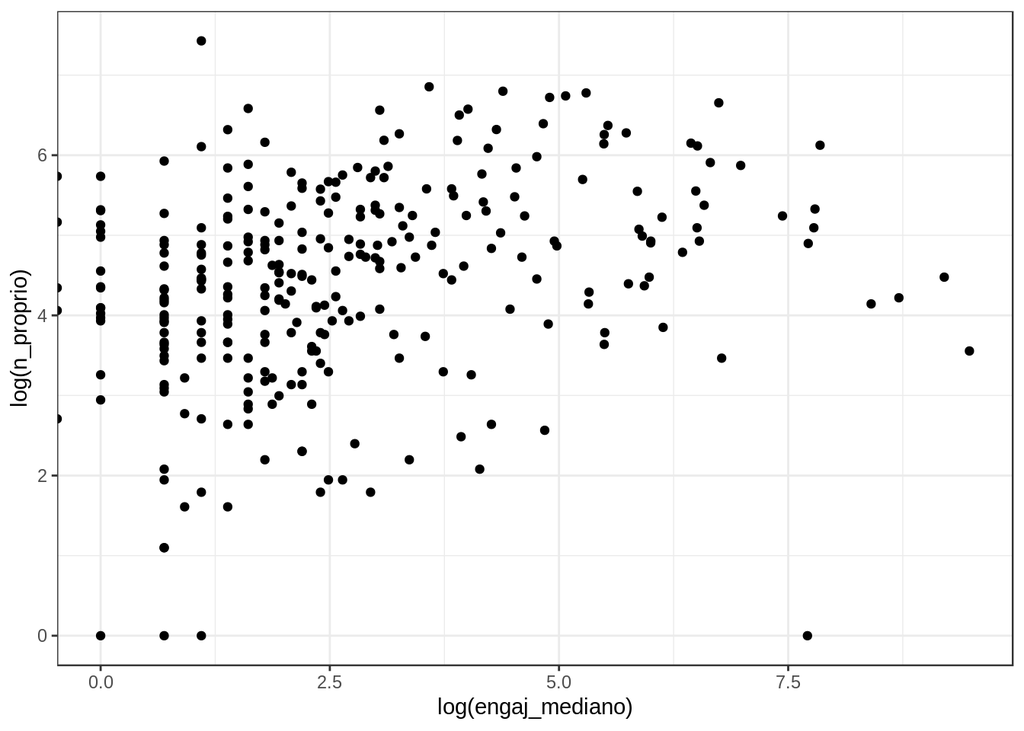

```r
atividade %>% ggplot(aes(x = log(engaj_mediano), y = log(n_proprio))) +
geom_point()
```

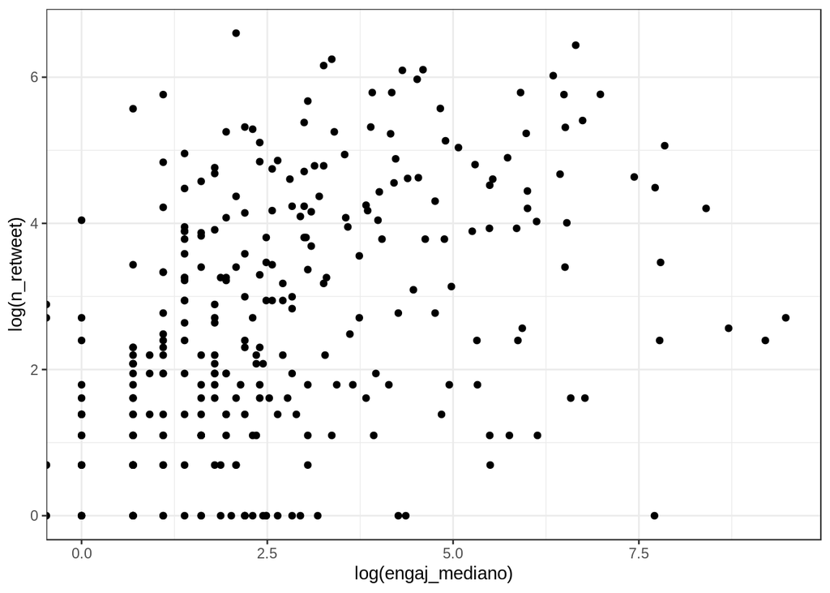

```r
atividade %>% ggplot(aes(x = log(engaj_mediano), y = log(n_retweet))) +
geom_point()
```

```r
atividade <- atividade %>% filter(engaj_mediano > 0)

modelo_eng_mediano <- lm(log(engaj_mediano) ~ casa + log(segue) +  log(seguidores) + log(n_proprio) + log(n_retweet),
                       data = atividade)


glance(modelo_eng_mediano)
```

| r.squared | adj.r.squared | sigma | statistic | p.value | df | logLik | AIC | BIC | deviance | df.residual |
| --- | --- | --- | --- | --- | --- | --- | --- | --- | --- | --- |
| 0.5728301 | 0.5653095 | 1.309042 | 76.16818 | 1.977974e-50 | 6 | -486.5564 | 987.1128 | 1012.802 | 486.6598 | 284 |

```r
tidy(modelo_eng_mediano)
```

| term | estimate | std.error | statistic | p.value |
| --- | --- | --- | --- | --- |
| (Intercept) | -1.8115840 | 0.47825804 | -3.787880 | 1.854710e-04 |
| casasenado | -0.2405244 | 0.19389411 | -1.240493 | 2.158168e-01 |
| log(segue) | -0.3410067 | 0.06123723 | -5.568617 | 5.951343e-08 |
| log(seguidores) | 0.7438113 | 0.04619705 | 16.100840 | 6.864527e-42 |
| log(n_proprio) | -0.1477701 | 0.08078025 | -1.829285 | 6.840533e-02 |
| log(n_retweet) | 0.2813467 | 0.06038591 | 4.659146 | 4.886049e-06 |

No modelo relacionando o engajamento mediano podemos perceber que ser do senado diminui seu engajamento mediano de forma -0,24 (valor maior que o obtido no engajemnto total). Novamente na quantidade de pessoas que o politico segue obtivemos que o influencia de forma negativa em seu engajamento mediano. A quantidade de seguidores de retweets influência em forma positiva com os valores 0.74 e 0.28 respectivamente. Uma coisa que chamou atenção é que a quantidade de tweets proprios influência de forma negativa no engajamento mediano. O que não era esperado logicamente. Porém foi observado no plot entre as variáves que não parece exstir uma relação linear entre o n_twewts e engaj_mediano.